# GEOG 6000 Lab Plotting with ggplot2

As before, we can use an extra variable to identify different parts of the data set. The Gapminder data contains a column indicating which continent the observations came from. We’ll use this first to color the points by changing the aesthetic:

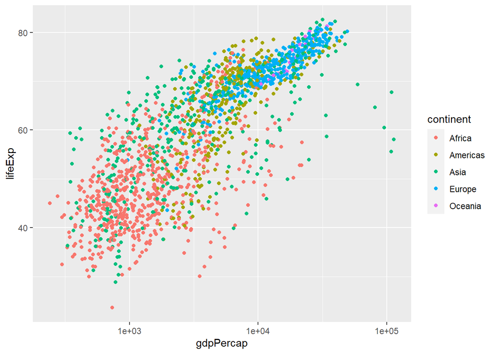

```r
myplot + geom_point(aes(color = continent))
```

If we now add a best fit line, however, we only get a single line for the whole dataset:

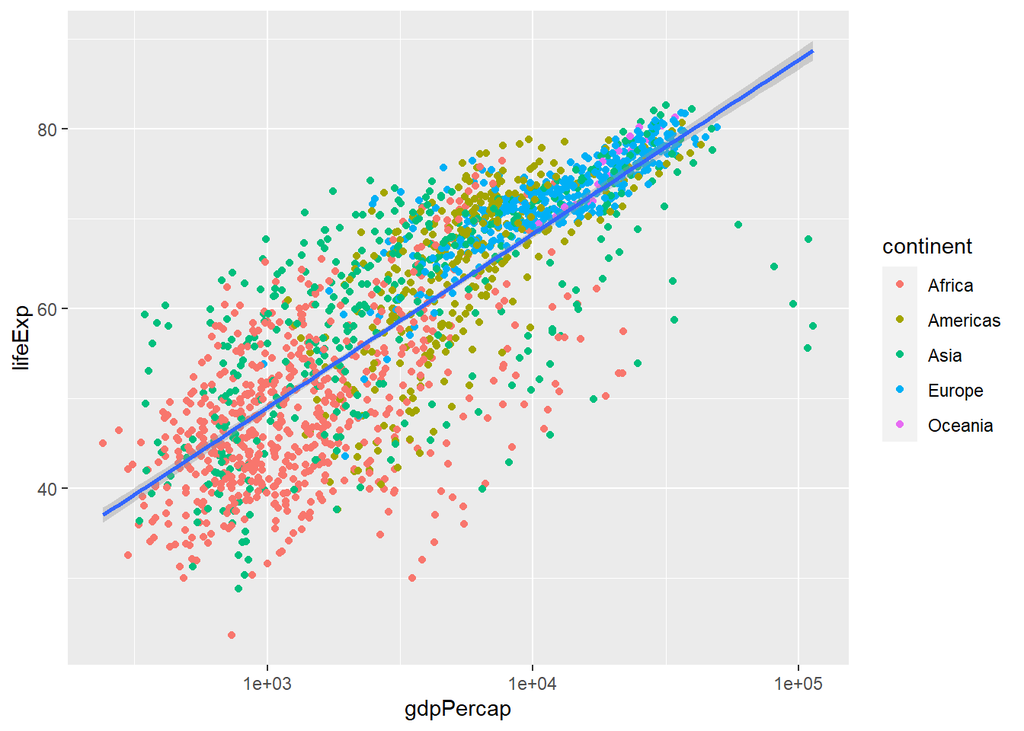

```r
myplot +
  geom_point(aes(color = continent)) +
  geom_smooth(method = 'lm')
```

This is a little tricky to explain, but basically, we have only changed the aesthetic in the geometry of the points, rather than the underlying `ggplot` object. The simplest way around this is to remake the object with the color included, then add the smoother:

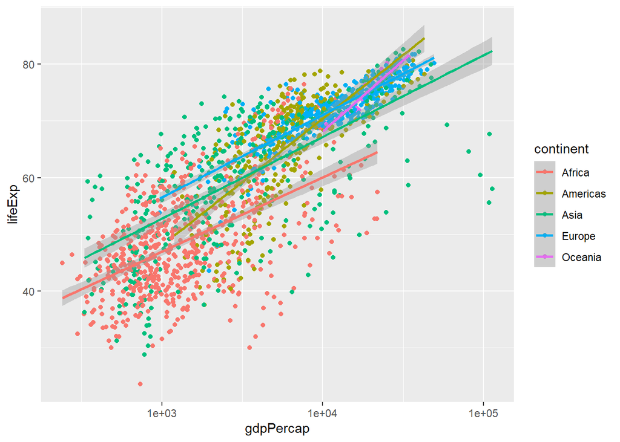

```r
myplot <- ggplot(gapdata, aes(x = gdpPercap, y = lifeExp, color = continent)) + scale_x_log10()

myplot +
  geom_point() +
  geom_smooth(method='lm')
```

Note that if you drop the `geom_point()`, you will just obtain the trend lines.